# Analysing dataset as a Complex System

Niels van Berkel and Vassilis Kostakos

6 December 2019

```r
library(rEDM)
library(dplyr)
library(zoo)
library(ggplot2)
library(reshape2)
library(doParallel)
library(foreach)
```

# Correlation vs Causality analysis

Tutorial from the [rEMD package](https://cran.r-project.org/web/packages/rEDM/vignettes/rEDM-tutorial.html).

We need a dataset with at least these columns:

- device_id (must be integer, from 1 and upwards)
- date
- hour
- columns with performance variable, eg. battery, notifications, usage, etc.

## Step 1: Find the optimum E: Embedding dimensions

The first step is to perform a simple analysis to see which is the optimum value of E (Embedding dimension) for our data (delta values).

```r
embedding_dimension <- function(participant_id, ts, maxE) {
    # browser()
    cutoff <- floor(nrow(ts) * 0.7)
    lib <- c(1, cutoff)
    pred <- c(cutoff + 1, nrow(ts))
    simplex_output1 <- simplex(ts[, 1], lib, pred, E = 1:maxE)
    simplex_output2 <- simplex(ts[, 2], lib, pred, E = 1:maxE)
    par(mar = c(4, 4, 1, 1), mgp = c(2.5, 1, 0))  # set up margins for plotting

    simplex_output1[, 6:6][is.na(simplex_output1[, 6:6])] = 0
    simplex_output2[, 6:6][is.na(simplex_output2[, 6:6])] = 0

    if (!is.na(sum(simplex_output1$rho)) & !is.na(sum(simplex_output2$rho))) {
        plot(simplex_output1$E, simplex_output1$rho, type = "l", xlab = "Embedding Dimension (E)",
            ylab = "Forecast Skill (rho)", main = paste("P", participant_id,
                "-", colnames(ts)[1], sep = " "))
        plot(simplex_output2$E, simplex_output2$rho, type = "l", xlab = "Embedding Dimension (E)",
            ylab = "Forecast Skill (rho)", main = paste("P", participant_id,
                "-", colnames(ts)[2], sep = " "))
        return(c(which.max(simplex_output1$rho), which.max(simplex_output2$rho)))
    } else return(NA)
}
```

## Step 2: Test for nonlinearity

This step ensures that the data is nonlinear rather than auto-correlated. If in the produced graphs, the forecast ability is greatest when theta == 0, then this means the data is autocorrelated. If the prediction is greatest when theta > 0, then the data is non-linear. We should discard participants whose data is auto-correlated.

```r
test_for_nonlinearity <- function(participant_id, ts, theE) {
    # browser()

    cutoff <- floor(nrow(ts) * 0.7)
    lib <- c(1, cutoff)
    pred <- c(cutoff + 1, nrow(ts))
    smap_output1 <- s_map(ts[, 1], lib, pred, E = theE[1])
    smap_output2 <- s_map(ts[, 2], lib, pred, E = theE[2])
    par(mar = c(4, 4, 1, 1), mgp = c(2.5, 1, 0))

    tryCatch({
        plot(smap_output1$theta, smap_output1$rho, type = "l", xlab = "Nonlinearity (theta)",
            ylab = "Forecast Skill (rho)", main = paste("P", participant_id,
                "-", colnames(ts)[1], sep = " "))
        plot(smap_output2$theta, smap_output2$rho, type = "l", xlab = "Nonlinearity (theta)",
            ylab = "Forecast Skill (rho)", main = paste("P", participant_id,
                "-", colnames(ts)[2], sep = " "))
    }, error = function(e) NA)

    # we return the value of theta for which rho is maximised
    return(c(smap_output1$theta[which.max(smap_output1$rho)], smap_output2$theta[which.max(smap_output2$rho)]))
}
```

## Step 3: Convergent Cross Mapping (CCM)

In the previous step we find the optimum E. Next, we perform the CCM analysis using that E.

```r
run_ccm <- function(participant_id, ts, theE, var1, var2) {
    #print(participant_id)
    #browser()

    # Define the sequence of window sizes that we consider
    # sizes <- seq(floor(nrow(ts) * 0.1), nrow(ts), by = floor(nrow(ts)/10))
    # sizes <- seq(10, 100, by = 10)
    # Consider 8-hour windows as library sizes
    sizes <- seq(1, 4*18, by = 1)

    v1_xmap_v2 <- ccm(ts, E = theE[1], lib_column = var1, target_column = var2,
        lib_sizes = sizes, num_samples = 100, random_libs = TRUE, replace = TRUE,
        silent = TRUE)
    v2_xmap_v1 <- ccm(ts, E = theE[2], lib_column = var2, target_column = var1,
        lib_sizes = sizes, num_samples = 100, random_libs = TRUE, replace = TRUE,
        silent = TRUE)

    v1_xmap_v2_means <- ccm_means(v1_xmap_v2)
    v2_xmap_v1_means <- ccm_means(v2_xmap_v1)

    par(mar = c(4, 4, 1, 1), mgp = c(2.5, 1, 0))  # set up margins for plotting
    y1 <- v1_xmap_v2_means$rho
    y2 <- v2_xmap_v1_means$rho

    # Ocassionally the y values are NaN or NA (result of missing data?)
    # Replace those with 0 (happens rarely, but crashes the code)
    y1[is.nan(y1)] = 0
    y2[is.nan(y2)] = 0
    y1[is.na(y1)] = 0
    y2[is.na(y2)] = 0

    # Calculation of the Asymptotes
    temp <- sortedXyData(v1_xmap_v2_means$lib_size, y1, tempdf)
    asymp1 <- stats::NLSstRtAsymptote(temp)
    temp <- sortedXyData(v2_xmap_v1_means$lib_size, y2, tempdf)
    asymp2 <- stats::NLSstRtAsymptote(temp)
    temp <- NULL
    df <- NULL

    plot(v1_xmap_v2_means$lib_size, y1, type = "l", col = "red", xlab = "Library Size",
        ylab = "Cross Map Skill (rho)", ylim = c(0, 1), main = paste("Participant",
            participant_id, sep = " "))
    lines(v2_xmap_v1_means$lib_size, y2, col = "blue")
    # Add a dotted line to indicate the magnitude of the cross-correlation
    # between the variables
    abline(h = abs(cor(ts[1], ts[2])), lty = 2)
    abline(h = asymp1, lty = 3, col = "red")
    abline(h = asymp2, lty = 3, col = "blue")
    legend(x = "topleft", legend = c(paste(var2, "drives", var1, sep = " "),
        paste(var1, "drives", var2, sep = " ")), col = c("red", "blue"),
        lwd = 1, bty = "n", inset = 0.02, cex = 0.8)

    # Absolute difference between the two assymptotes
    asympdifference <- asymp2 - asymp1

    # Calculate the RoC for each assymptote Calculate Average Rate of
    # Change for Asymp 1
    # avgRoC <- round((head(y1,1) - tail(y1, 1)) /
    # (head(v1_xmap_v2_means$lib_size,1) - tail(v1_xmap_v2_means$lib_size,
    # 1)) * 100, 8)
    avgRoC1 <- tail(y1, 1) - head(y1, 1)

    # Calculate Average Rate of Change for Asymp 2 avgRoC <-
    # round((head(y2,1) - tail(y2, 1)) / (head(v2_xmap_v1_means$lib_size,1)
    # - tail(v2_xmap_v1_means$lib_size, 1)) * 100, 8)
    avgRoC2 <- tail(y2, 1) - head(y2, 1)

    # Calculate the absolute difference between participant's correlation
    # and largest asymptote
    corvalue <- abs(cor(ts[1], ts[2]))
    asymp <- max(asymp1, asymp2)
    cordifference <- asymp - corvalue[, 1]

    values <- list(participant = participant_id, asympdifference = asympdifference,
        RoC1 = avgRoC1 * 100, RoC2 = avgRoC2 * 100, asymp = asymp, asymp1 = asymp1,
        asymp2 = asymp2, cordifference = cordifference, cor = corvalue[,
            1])
    return(values)
}
```

## Do the analysis

We must extract complete time series per participant. For each participant we run through every step of the analysis. Here is how to interpret the results:

Step 1: The optimum E must be a global maximum. If the values are always increasing, we need to search for larger E values.

Step 2: We should discard participants whose data is auto-correlated (not engough data perhaps?)

Step 3: In the CCM results, we look for * a clear and positive convergene of the CCM values, * check to make sure the CCM convergence value it is above the correlation (black dashed line) * identify which of the blue/red lines is above the other. Then that relationship is the strongest one.

Step 4: Visualise the results for all participants

```r
# d: the dataframe. Must have the following columns: device_id (must be
# integer, from 1 and upwards); date; hour;

# howmany: how many participants to do. Enter 0 to do all

# var1, var2: the column names of the df that we want to analyse

# lagdata: calculate the difference between data rows or keep the raw values?

do_the_analysis_parallel <- function(d, howmany, var1, var2, fillgaps = TRUE, lagdata = TRUE) {
    # browser()

    participants <- d %>% distinct(device_id)
    if (howmany <= 0) {
        num_of_participants <- participants %>% count() %>% as.numeric
    } else {
        num_of_participants <- howmany
    }

    valuesList <- list()
    # Parallelise the analysis for each participant
    cores = detectCores()
    cl <- makeCluster(cores[1] - 1, outfile = "errors.txt") # Not to overload your computer.
    registerDoParallel(cl)
    seed <- sample(1000:9999, 1)  # Use this when saving files in each thread.

    # When parallelising, we need to inject into each worker thread the
    # packages and variables that it needs.
    output <- foreach(i = 1:num_of_participants, .combine = rbind, .packages = c("dplyr",
        "rEDM", "zoo", "reshape2"), .export = c("embedding_dimension",
        "test_for_nonlinearity", "run_ccm", "valuesList", "seed")) %do% #TODO
        {
            #browser()

            id <- participants$device_id[i]
            skip_this_participant <- FALSE

            # Because there may be missing observations, make sure we add those
            # rows and set them to NA. This will make the time series complete (e.g.
            # 24 hourly entries per day)

            participant_data <- d %>% filter(device_id == id)


            if (fillgaps) {
                hours <- data.frame(hour = 0:23)
                tmp <- participant_data %>% distinct(date)
                all_combinations <- expand.grid(hour = 0:23, date = tmp$date)
                r <- full_join(all_combinations, participant_data, by = c("date",
                  "hour"))
                participant_data <- r
            }
            participant_data <- participant_data %>% select(!!rlang::sym(var1),
                !!rlang::sym(var2))

            # Calculate lag data instead of keeping the raw data
            if (lagdata) {
                names <- colnames(participant_data)
                participant_data <- data.frame(diff(participant_data[,1]), diff(participant_data[,2]))
                colnames(participant_data) <- names
            }

            # Convert NAs to 0
            participant_data[1][is.na(participant_data[1])] <- 0
            participant_data[2][is.na(participant_data[2])] <- 0

            # Ignore participants with empty data or little data
            if (nrow(participant_data) < 10) {
                message(paste("Skipping participant", id, "due to limited data."))
                skip_this_participant <- TRUE
                ## Uncomment the line below to speed up analysis. We can give up on
                ## participants early.
                return()
            }

            # Configure plots in a row for each thread
            pdf(sprintf("images/%04d_participant_%03d.pdf", seed, id),
                width = 10, height = 2)
            par(mfrow = c(1, 5))  # widths=c(2,2,2), heights=c(1,1,1))

            # Step 1
            theE <- embedding_dimension(id, participant_data, maxE = 15)
            if (is.na(theE)) {
                # message(paste('Skipping participant',i,'due to invalid E'))
                # skip_this_participant <- FALSE
                theE <- c(1, 1)
                # dev.off() return()
            }

            # Step 2
            theta <- test_for_nonlinearity(id, participant_data, theE)
            if (length(theta) == 0)
                theta <- c(0, 0)
            # if((theta < 0.8) | (theta > 6)) {
            # message(paste('Skipping participant',i, 'due to data not being non-linear'))
            # skip_this_participant <- TRUE dev.off() return() }

            # Step 3
            values <- run_ccm(id, participant_data, theE, var1, var2)
            tmp <- which.max(c(values$asymp1, values$asymp2))

            if (c(values$RoC1, values$RoC2)[tmp] < 0) {
                message(paste("Skipping participant", id, "strongest CCM line is not converging."))
                skip_this_participant <- FALSE
            }

            # store all the values used for final plot
            values$ignore <- skip_this_participant

            # close the plot device for the thread
            dev.off()
            return(values)
        }

    # Stop the parallelisation
    stopCluster(cl)

    # browser()

    # Return as dataframe with numeric values
    output_formated <- NULL
    if (!is.null(output)) {
        if (nrow(output) > 2) {
            output_formated <- data.frame(matrix(unlist(output), nrow = nrow(output)))
            colnames(output_formated) <- colnames(output)
        }
    }

    return(output_formated)
}
```

## Step 4: Summarise all participants

Now that we have created individual plots per participant, we want to construct a single image displaying what is going on in all the data for all participants.

```r
plot_summary <- function(results, var1, var2) {
    knitr::opts_chunk$set(fig.path = "images/")

    # The parallelised functions return the data in a slightly different
    # format, so we need to do some processing to get the results into the
    # required format.
    if (!is.data.frame(results)) {
        # Convert list of values / participant to a dataframe
        df <- do.call(rbind, lapply(valuesList, data.frame, stringsAsFactors = FALSE))
        df <- df[complete.cases(df$RoC1), ]
        df <- df[complete.cases(df$RoC2), ]
    } else {
        df <- results
        df$ignore <- as.logical(df$ignore)
    }

    df$ignore[df$cordifference < 0] <- TRUE

    # Calculate the mean asymptote difference for participants that we
    # retain (discard the ones we ignore).
    # Exclude infinite values in mean calculation.
    #browser()
    the_mean <- mean(df$asympdifference[df$ignore == 0])
    the_mean <- round(the_mean, digits = 3)
    # Exclude infinite values in SD calculation.
    the_sd <- sd(df$asympdifference[df$ignore == 0])
    the_sd <- round(the_sd, digits = 3)

    # Define plot margin based on plot values.
    plot_mar <- round(max(max(abs(df$asympdifference), na.rm = TRUE), max(abs(df$cordifference),
        na.rm = TRUE)), 1) + 0.1

    df$ignore <- as.factor(df$ignore)
    levels(df$ignore)[levels(df$ignore) == "TRUE"] <- "Invalid"
    levels(df$ignore)[levels(df$ignore) == "FALSE"] <- "Valid"

    plot(ggplot(df, aes(x = df$asympdifference, y = df$cordifference)) +
        geom_hline(yintercept = 0, linetype = "dashed") + geom_vline(xintercept = 0,
        linetype = "dashed") + geom_point(aes(colour = ignore), size = 1.8) +
        scale_color_manual(values = c(Invalid = "#BD5200", Valid = "#008698")) +
        ylab("Difference to correlation\n(significance)") + xlab(paste("Difference between asymptotes (effect size)\n",
        var2, "is stronger", sprintf("↔"), var1, "is stronger\n", "Mean:",
        the_mean, "SD:", the_sd)) + theme_minimal() + theme(axis.title = element_text(size = 9),
        panel.grid.minor = element_blank(), legend.title = element_blank()) +
        geom_vline(xintercept = c(the_mean), linetype = "dotted") + xlim(-0.9,
        0.9) + ylim(-0.9, 0.9))

    df.plot <- melt(df[, c("asymp1", "asymp2", "cor")], id.vars = NULL)
    df.plot$variable <- as.factor(df.plot$variable)

    levels(df.plot$variable)[levels(df.plot$variable) == "asymp1"] <- paste(var2,
        "drives", var1, sep = " ")
    levels(df.plot$variable)[levels(df.plot$variable) == "asymp2"] <- paste(var1,
        "drives", var2, sep = " ")
    levels(df.plot$variable)[levels(df.plot$variable) == "cor"] <- "Correlation"

    ggplot(df.plot, aes(x = value, colour = variable, fill = variable)) +
        geom_density(alpha = 0.25) + theme_minimal() + theme(axis.title = element_text(size = 7),
        panel.grid.minor = element_blank())
}
```

# Investigate causality between variables

We try to investigate how the various variables affect each other. This is an assesment of causality rather than correlation.

```
## 'data.frame':    1740 obs. of  6 variables:
##  $ device_id    : Factor w/ 5 levels "10a38b2ac882353c",..: 1 1 1 1 1 1 1 1 1 1 ...
##  $ date         : Factor w/ 114 levels "2016-01-01","2016-01-11",..: 2 2 2 2 2 2 2 3 3 3 ...
##  $ hour         : int  17 18 19 20 21 22 23 0 1 2 ...
##  $ battery_level: int  45 40 35 25 85 80 95 85 85 80 ...
##  $ notifications: int  11 9 8 9 13 23 185 24 6 13 ...
##  $ session_count: int  22 27 31 18 60 33 29 48 4 10 ...
```

```
## Skipping participant 10a38b2ac882353c strongest CCM line is not converging.
```

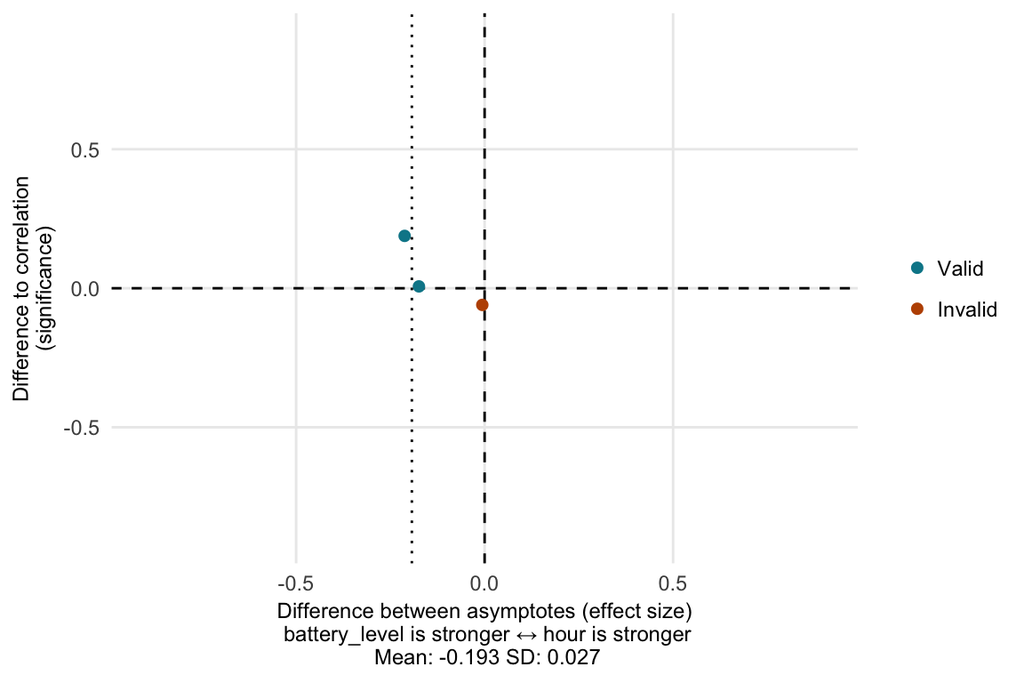

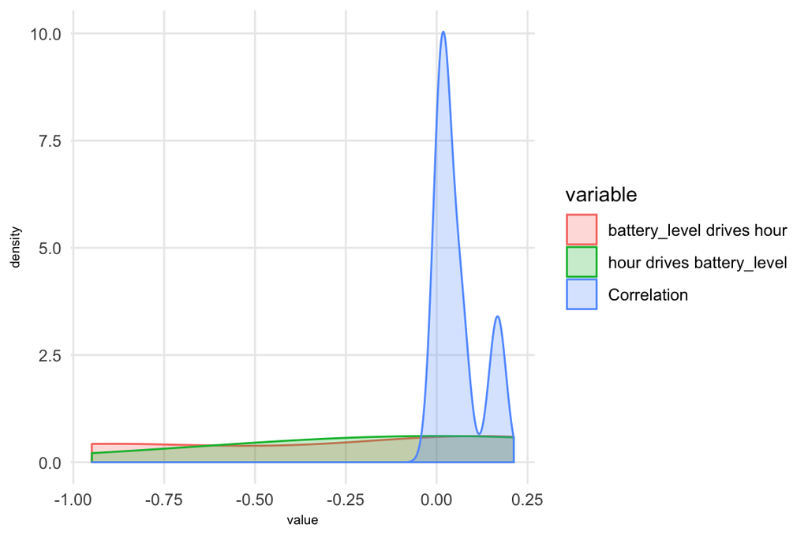